# project

Noah Hansen, Yuhan Dai, Steven Hizmi

4/19/2021

## questons on data (TODO remove this section for final draft)

```
## # A tibble: 6 x 11
##   cbsa  cbsa_code date         aqi category param site  num_sites  year month
##   <chr>     <dbl> <date>     <dbl> <chr>    <chr> <chr>     <dbl> <dbl> <dbl>
## 1 Akro~     10420 1980-01-01   112 Unhealt~ SO2   39-1~         3  1980     1
## 2 Akro~     10420 1980-01-02    43 Good     CO    39-1~         3  1980     1
## 3 Akro~     10420 1980-01-03    49 Good     SO2   39-1~         3  1980     1
## 4 Akro~     10420 1980-01-04    76 Moderate SO2   39-1~         4  1980     1
## 5 Akro~     10420 1980-01-05    89 Moderate SO2   39-1~         4  1980     1
## 6 Akro~     10420 1980-01-06   130 Unhealt~ SO2   39-1~         4  1980     1
## # ... with 1 more variable: wday <ord>
```

This doesn’t mean anything, really, as it combines all pollutants (maybe that is okay though?). Param is really ‘Defining Parameter’, which means it is the param chosen for the day from multiple that were measured. My guess is that they chose the pollutant with the worst AQI. If one pollutant is bad, then it probably doesn’t matter too much if other pollutants are not as bad. Either way it is unhealthy for senitive groups or everyone. However, having two pollutants at moderate has to be worse than just one.

```
## # A tibble: 40 x 2
##     year avg_aqi
##    <dbl>   <dbl>
##  1  2019    39.2
##  2  2016    40.5
##  3  2018    41.1
##  4  2017    41.6
##  5  2015    41.7
##  6  2014    42.4
##  7  2013    43.0
##  8  2009    43.2
##  9  2010    45.5
## 10  2011    45.6
## # ... with 30 more rows
```

TODO: The parameter is different depending on the date. If a CBSA reports multiple pollutants in a day, only one is chosen in the dataset. Is this okay?

```
## # A tibble: 361 x 11
##    cbsa  cbsa_code date         aqi category param site  num_sites  year month
##    <chr>     <dbl> <date>     <dbl> <chr>    <chr> <chr>     <dbl> <dbl> <dbl>
##  1 Alto~     11020 2018-02-08    49 Good     PM2.5 42-0~         1  2018     2
##  2 Alto~     11020 2018-02-09    59 Moderate PM2.5 42-0~         1  2018     2
##  3 Alto~     11020 2018-02-10    79 Moderate PM2.5 42-0~         1  2018     2
##  4 Alto~     11020 2018-02-11    56 Moderate PM2.5 42-0~         1  2018     2
##  5 Alto~     11020 2018-02-12    41 Good     Ozone 42-0~         1  2018     2
##  6 Alto~     11020 2018-02-13    39 Good     PM2.5 42-0~         1  2018     2
##  7 Alto~     11020 2018-02-14    55 Moderate PM2.5 42-0~         1  2018     2
##  8 Alto~     11020 2018-02-15    30 Good     PM2.5 42-0~         1  2018     2
##  9 Alto~     11020 2018-02-16    35 Good     Ozone 42-0~         1  2018     2
## 10 Alto~     11020 2018-02-17    31 Good     Ozone 42-0~         1  2018     2
## # ... with 351 more rows, and 1 more variable: wday <ord>
```

This table shows the average and maximum gaps in reporting each criteria pollutant for each CBSA. Maybe we would want to exclude some of the pollutants that are not measured very often per CBSA code. We can repeat this analysis for different time periods instead of the whole 40 years, as some stop reporting certain values for years at a time.

```
## # A tibble: 2,496 x 4
## # Groups:   cbsa_code [697]
##    cbsa_code param diff_avg diff_max
##        <dbl> <chr>    <dbl>    <dbl>
##  1     10100 PM10     24.9      4628
##  2     10100 PM2.5     3.37       21
##  3     10140 PM10     35.1      2616
##  4     10140 PM2.5     1.01       20
##  5     10140 SO2       1.03       16
##  6     10260 PM2.5     5.16      864
##  7     10300 Ozone     2.10      218
##  8     10300 PM2.5     2.85       57
##  9     10380 PM2.5     4.03       51
## 10     10420 CO       44.8      1002
## # ... with 2,486 more rows
```

Displays the average difference in days for reporting each pollutant in a nicer format. Also shows what pollutants each CBSA reports

```
## # A tibble: 697 x 7
## # Groups:   cbsa_code [697]
##    cbsa_code  PM10 PM2.5   SO2 Ozone    CO   NO2
##        <dbl> <dbl> <dbl> <dbl> <dbl> <dbl> <dbl>
##  1     10100 24.9   3.37 NA    NA     NA   NA
##  2     10140 35.1   1.01  1.03 NA     NA   NA
##  3     10260 NA     5.16 NA    NA     NA   NA
##  4     10300 NA     2.85 NA     2.10  NA   NA
##  5     10380 NA     4.03 NA    NA     NA   NA
##  6     10420 86.9   2.22  2.28  3.19  44.8  9
##  7     10460  8.09 NA    NA    NA     NA   NA
##  8     10500 30.5   1.49  3.08 NA     NA   NA
##  9     10540  7.38  1.19 NA     1.05  NA   NA
## 10     10580 84.8   3.74  4.30  1.60  66.9  6.35
## # ... with 687 more rows
```

For analysis on all 40 years, we probably want at least 5 datapoints a year for a total sample of 200. The avg difference for this would be less than 73. Maybe not the best metric because one CBSA meets this standard but did not report for 37 years. If a CBSA has data for a pollutant daily, long periods do not bring the average down very much.

```
## # A tibble: 2,263 x 4
## # Groups:   cbsa_code [697]
##    cbsa_code param diff_avg diff_max
##        <dbl> <chr>    <dbl>    <dbl>
##  1     10100 PM10     24.9      4628
##  2     10100 PM2.5     3.37       21
##  3     10140 PM10     35.1      2616
##  4     10140 PM2.5     1.01       20
##  5     10140 SO2       1.03       16
##  6     10260 PM2.5     5.16      864
##  7     10300 Ozone     2.10      218
##  8     10300 PM2.5     2.85       57
##  9     10380 PM2.5     4.03       51
## 10     10420 CO       44.8      1002
## # ... with 2,253 more rows
```

## Analysis

> The following section groups the data by year and pollution type, then summarized the data by taking the mean of the AQI. The graph depicts the change of air quality data over the last 40 years. The horizontal line indicates the Good Level for AQI, below the line (50) means the air quality is satisfactory. The details regarding the levels of concern for AQI can be found here: https://www.airnow.gov/aqi/aqi-basics/

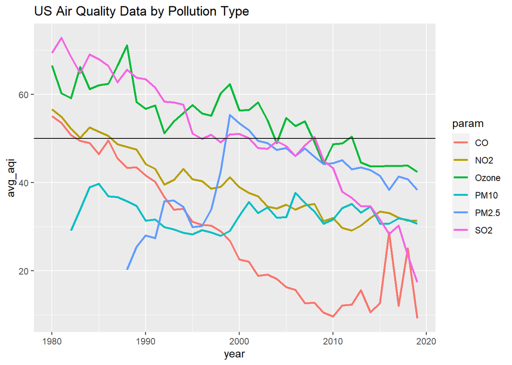

As shown above, US pollution overall is improving since the AQI is decreasing for most of the pollution type. However, there are drastic increases for both CO and PM2.5.

> The following section is trying to discover the trend of US vehicle usage from 1960 to 2019.  
> The data used in this section can be found here: https://www.bts.gov/content/us-vehicle-miles

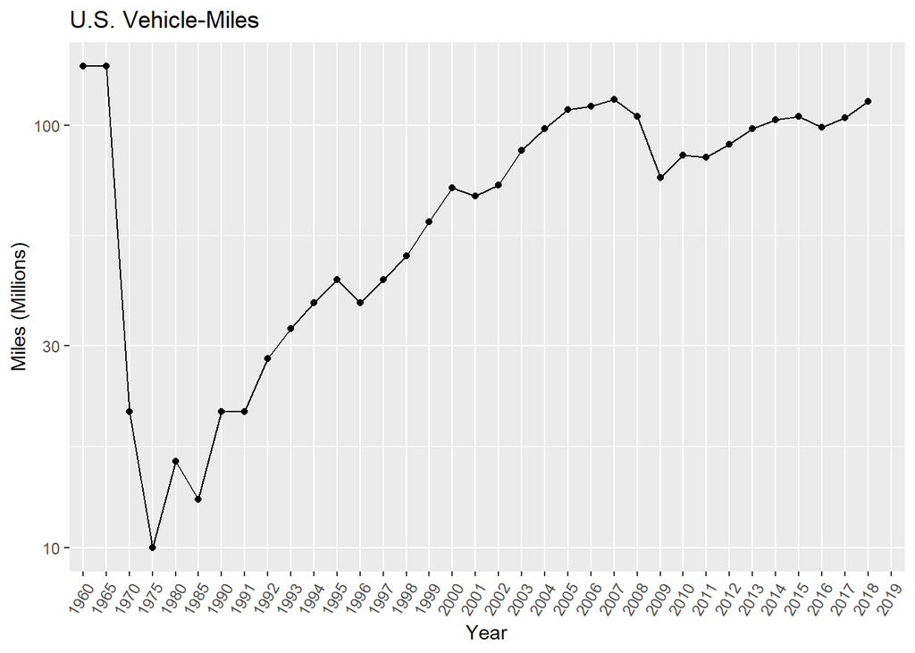

As shown above, the usage of vehicles in the US is siginificantly increasing over the past few decades. Due to the source of the data, between year 1960 and 1990, the discrepancy is 5 years instead of 1, which results in a steeper slope than from 1990 to 2019.

> The following section is to perform a linear regression on CO and PM2.5 level with US vehicle miles to see if there’s a significant relation between them.

```
##
## Call:
## lm(formula = CO ~ miles, data = mile_poll)
##
## Residuals:
##      Min       1Q   Median       3Q      Max
## -11.5419  -1.8648   0.0016   2.2332  13.3708
##
## Coefficients:
##             Estimate Std. Error t value Pr(>|t|)
## (Intercept) 41.96561    2.67050  15.715 4.15e-15 ***
## miles       -0.26547    0.03312  -8.016 1.30e-08 ***
## ---
## Signif. codes:  0 '***' 0.001 '**' 0.01 '*' 0.05 '.' 0.1 ' ' 1
##
## Residual standard error: 5.419 on 27 degrees of freedom
##   (1 observation deleted due to missingness)
## Multiple R-squared:  0.7041, Adjusted R-squared:  0.6932
## F-statistic: 64.25 on 1 and 27 DF,  p-value: 1.296e-08
```

```
##
## Call:
## lm(formula = PM2.5 ~ miles, data = mile_poll)
##
## Residuals:
##     Min      1Q  Median      3Q     Max
## -7.3669 -4.9238 -0.5672  2.0473 15.7011
##
## Coefficients:
##             Estimate Std. Error t value Pr(>|t|)
## (Intercept) 30.98023    2.98483  10.379 6.35e-11 ***
## miles        0.14737    0.03702   3.981 0.000465 ***
## ---
## Signif. codes:  0 '***' 0.001 '**' 0.01 '*' 0.05 '.' 0.1 ' ' 1
##
## Residual standard error: 6.057 on 27 degrees of freedom
##   (1 observation deleted due to missingness)
## Multiple R-squared:  0.3699, Adjusted R-squared:  0.3466
## F-statistic: 15.85 on 1 and 27 DF,  p-value: 0.0004651
```

According to the linear regressions above, the p values of miles for each pollutant are significant enough which indicates that there’s a correlation between US vehicle usage and pollutant level for PM2.5 and CO. However, since the slope for CO is negative, this indicate that the fluctuate of CO level might not related to the US vehicle usage.

#### Steve

**With the lockdowns during the Covid pandemic, it gave us an opportunity to see what happened to air pollution with less human activity in three Wisconsin counties: Dane, Milwaukee, and Waukesha counties. So we have collected county data over the last 6 years to compare with data during the lockdowns. We also collected daily data from 2020, from January to June (as that is the most updated data out there thus far).**

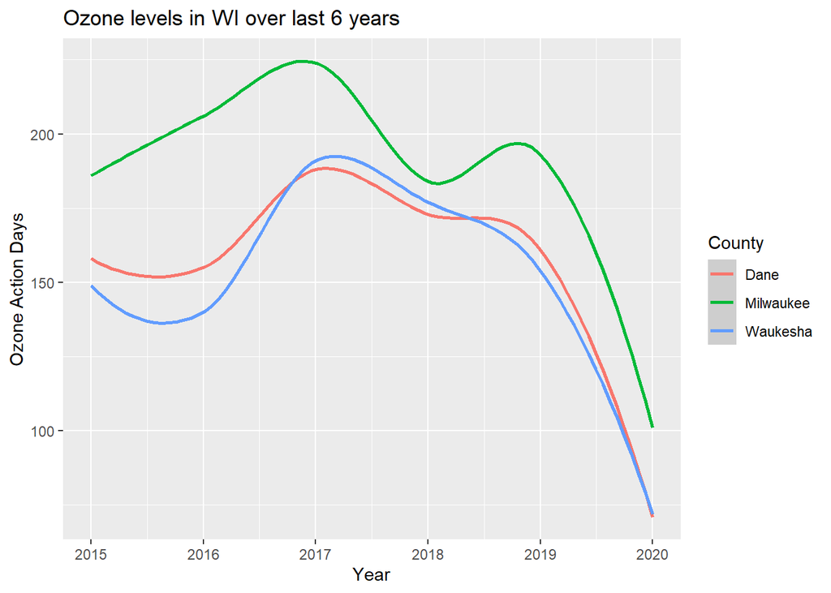

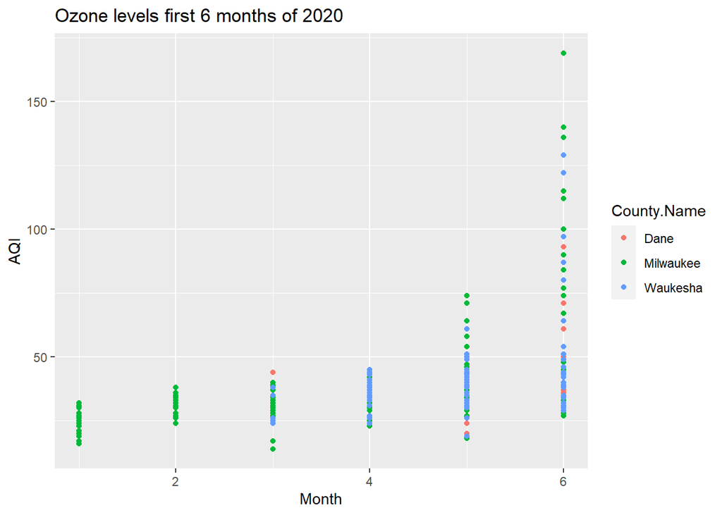

**Considering that the first lockdown in Wisconsin was March, the ozone levels don’t go beyond 50, which is deemed safe. The ozone levels don’t start increasing until May and June, which is to be expected as Ozone levels increase during summer. The question is: Did Covid have an affect on the Ozone levels or was it increased due to it being Summer? To see which is true, we decided to look at the daily data from 2019, with no stay at home orders to see how they compare.**

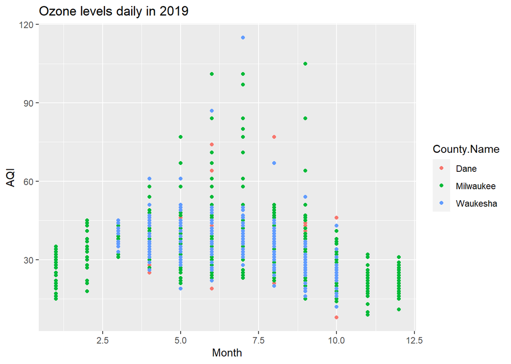

## Appendix

If you would like to see the code, it is [hosted on GitHub](https://github.com/stevehizmi/air-pollution-analysis)